# 2018-05-02 - Credit Card Fraud

Alex Pan

A tour of classification algorithms to detect credit card fraud, primarily using the caret package.

Data from [Kaggle](https://www.kaggle.com/mlg-ulb/creditcardfraud/data).

## 1. Libraries

```r
library(tidyverse)
theme_set(theme_bw())
library(caret)
library(corrplot)
library(gridExtra)


set.seed(123456)
```

## 2. Defining Functions

```r
# Chosen at random
test.class <- function(model, test=credit_dev, cl=credit_dev$Class, positive = "1") {
    # Given a model 'model', predicts the test classifier. Then returns a confusion matrix for the test data.
    # Model = A model object (ex., glm, random forest, knn)
    # test = data.frame containing all the variables used in the model
    # cl = A factor of the true classifications for the variable of interest in 'test'
    # positive = Which outcome is the outcome of interest? By default, it is 1.
   predict <- predict(model, test)
   return(confusionMatrix(predict, cl, positive = positive))
}

scaleFUN <- function(x) sprintf("%.2f", x)
```

## 3. Load in Data

These data are all PCA variables (i.e., these are not the actual variables)

### Data structure and Descriptive Stats:

```r
glimpse(credit)
```

```
Observations: 284,807
Variables: 31
$ Time   <int> 0, 0, 1, 1, 2, 2, 4, 7, 7, 9, 10, 10, 10, 11, 12, 12, 1...
$ V1     <dbl> -1.359807, 1.191857, -1.358354, -0.966272, -1.158233, -...
$ V2     <dbl> -0.0727812, 0.2661507, -1.3401631, -0.1852260, 0.877736...
$ V3     <dbl> 2.5363467, 0.1664801, 1.7732093, 1.7929933, 1.5487178, ...
$ V4     <dbl> 1.3781552, 0.4481541, 0.3797796, -0.8632913, 0.4030339,...
$ V5     <dbl> -0.3383208, 0.0600176, -0.5031981, -0.0103089, -0.40719...
$ V6     <dbl> 0.4623878, -0.0823608, 1.8004994, 1.2472032, 0.0959215,...
$ V7     <dbl> 0.2395986, -0.0788030, 0.7914610, 0.2376089, 0.5929407,...
$ V8     <dbl> 0.09869790, 0.08510165, 0.24767579, 0.37743587, -0.2705...
$ V9     <dbl> 0.3637870, -0.2554251, -1.5146543, -1.3870241, 0.817739...
$ V10    <dbl> 0.0907942, -0.1669744, 0.2076429, -0.0549519, 0.7530744...
$ V11    <dbl> -0.5515995, 1.6127267, 0.6245015, -0.2264873, -0.822842...
$ V12    <dbl> -0.6178009, 1.0652353, 0.0660837, 0.1782282, 0.5381956,...
```

[output cut: 18 more lines]

### Missingness

```r
colSums(is.na(credit))
```

```
  Time     V1     V2     V3     V4     V5     V6     V7     V8     V9
     1      0      0      0      0      0      0      0      0      0
   V10    V11    V12    V13    V14    V15    V16    V17    V18    V19
     0      0      0      0      0      0      0      0      0      0
   V20    V21    V22    V23    V24    V25    V26    V27    V28 Amount
     0      0      0      0      0      0      0      0      0      0
 Class
     0
```

```r
credit <- na.omit(credit)
```

## 3. Descriptive Stats

These data are composed of anonymized variables that have been reduced by PCA. For that reason descriptive stats aren’t as important to us as they would normally be, since we have absolutely no way of interpreting them.

Most transactions are very small, but some are very large. Larger transactions *may* be more associated with fraud.

```r
summary(credit$Amount)
```

```
   Min. 1st Qu.  Median    Mean 3rd Qu.    Max.
    0.0     5.6    22.0    88.3    77.2 25691.2
```

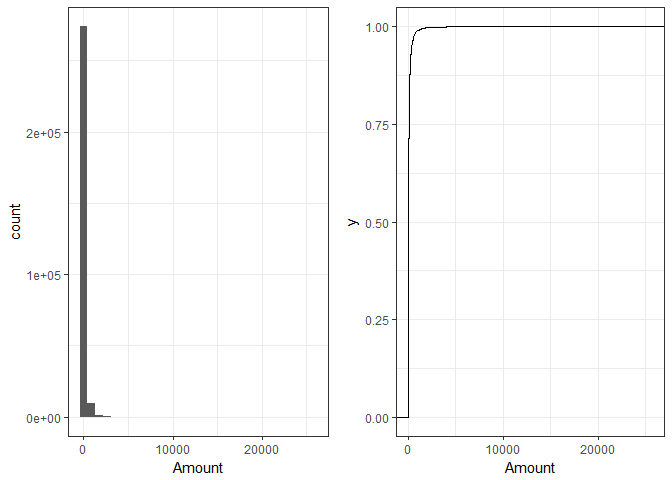

```r
p1 <- ggplot(credit) +
    aes(x = Amount) +
    geom_histogram()

p2 <- ggplot(credit) +
    aes(x = Amount) +
    stat_ecdf()

grid.arrange(p1, p2, ncol = 2)
```

Time is described as *Number of seconds elapsed between each transaction (over two days)*. I’m not 100% clear on what this means, but judging from the bimodal pattern plotted below I would suspect that data collection began around midnight and continued for 48 hours.

This is interesting because if fraud is more common at certain times of the day, we should really change this feature to ‘represent time of day’ rather than ‘seconds since start’

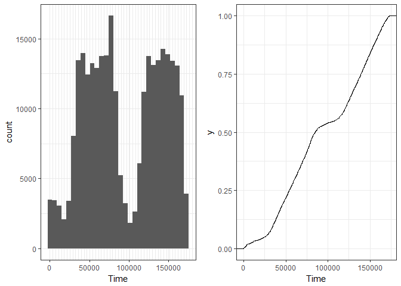

```r
p1 <- ggplot(credit) +
    aes(x = Time) +
    geom_histogram() +
    scale_x_continuous(minor_breaks = seq(0, 180000, 3600))

p2 <- ggplot(credit) +
    aes(x = Time) +
    stat_ecdf()

grid.arrange(p1, p2, ncol = 2)
```

In fact, let’s make a new feature now. There are a few ways to split this up–looking only at time of day, or assigning each time a score based on how many other transactions are happening around that time. E.g., breaking up transactions into 10 or 30 minute blocks and making a new variable that describes how many transactions took place in that period.

For simplicity I will just use ‘time of day’, which atleast roughly increases as ‘time of day’ increases.

If fraud is actually associated with Time it will *probably* be non-monotonic (eg., more active at very early and very late time rather than trending up or down as ‘time of day’ increases). For that reason a non-linear classifier would probably do better if Time is important.

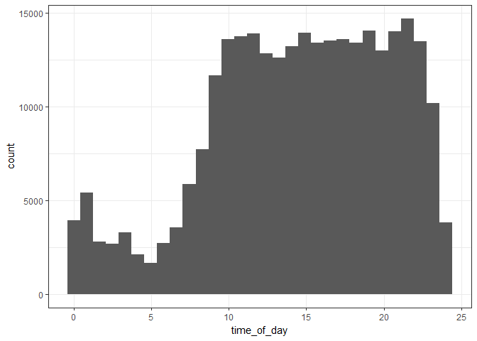

```r
credit <- credit %>%
    mutate(time_of_day = ifelse(Time < 86400, Time / 3600, (Time - 86400) / 3600))

ggplot(credit) +
    aes(x = time_of_day) +
    geom_histogram() +
    scale_x_continuous(minor_breaks = seq(0, 180000, 3600))
```

## 4. Data Partitioning

1 is credit card fraud, 0 is a normal transaction.

Only 0.2% (492) of the entries are actual fraud! We will need to take special approaches to handle these unbalanced data.

```r
summary(credit$Class)
```

```
     0      1
284314    492
```

We start by sampling data for each of the training, CV (development), and test sets. We will then undersample the non-fraud cases.

caret’s `createDataPartition` function works like `sample` in base R, except it makes sure that the response variable is balanced across the different data sets. This is especially important when the number of “events” is low.

```r
mask_train <- createDataPartition(credit$Class, p = 0.7, list = F)
credit_train <- credit[mask_train, ]

# Split the remaining 30% into CV and test sets. Unfortunately this is a convoluted process
mask_cv <- createDataPartition(credit$Class[-mask_train], p = 0.5, list = F)
credit_dev <- credit[mask_cv, ]
credit_test <- credit[-mask_train, ][-mask_cv, ]
```

#### Controls for model validation

Define the controls for each model fit. Here I’m using 5x5-fold CV.

```r
fit.controls <- trainControl(method = "repeatedcv",    # Bootstrapped CV
                             number = 5,    # number of CV
                             repeats = 5)    # number of repeats
```

## 5. Dealing with Unbalanced Classes:

I’m going to try and figure out which sampling methods are best for these data. For each sampling technique I will use a fairly simple random forest. If any sampling techniques seem to work better than others I will follow up on those specifically and try out other classifiers.

*(Note: For faster Rmarkdown rendering I’ve disabled the evaluation of the code and am just copying the output from the console)*

**Summary:**

- Oversampling, SMOTE, and even no sampling perform much better on the dev set compared to undersampling.
- Oversampling and No sampling produced the highest kappas in these random forest models. Unlike SMOTE and undersampling the training errors are somewhat reflective of the dev set errors, which make them more useful sampling techniques to train models on.
- Whereas undersampling, oversampling, and SMOTE tended to overfit the training data, no sampling performed better in the dev set compared to the training set. I’m not completely sure why this is the case. (a) I could be under-trained (this will be determined later); or (b) there may be overlap between positive and negative events in the training set that precludes very high training Kappa, whereas the dev set is more sparse (?).
- Running the sampling *inside* of cross-validation might improve the agreement between the training metrics and dev metrics.

I will move forward using oversampling, SMOTE, and no sampling and try some other classification models.

### 5.1. Undersampling

Undersampling involves censoring a large amount of data.

```r
## Note I am excluding 'Time' and 'Amount'

credit_train_downsampled <- downSample(x = credit_train,
                               y = credit_train$Class,
                               yname = "Class")

summary(credit_train_downsampled$Class)
```

```
  0   1
345 345
```

```r
kappas <- data.frame(mtry = NA, set = NA, kappa = NA)

for (mtry in c(1, 2, 4, 8, 12, 16)){
    set.seed(123456)
    fit_rf <- train(Class ~ . -Time,
                    data = credit_train_downsampled,
                    method = 'rf',
                    trControl = fit.controls,
                    tuneGrid = expand.grid(mtry = mtry),
                    n.trees = 3001,
                    metric = 'Kappa')

    fit_metrics <- test.class(fit_rf)
    kappas <- rbind(kappas, c(mtry, 'train', fit_rf$results$Kappa))
    kappas <- rbind(kappas, c(mtry, 'dev', fit_metrics$overall['Kappa']))
    print(paste('mtry: ', mtry))
    print(fit_rf$results$Kappa)
    print(fit_metrics)
}


kappas <- kappas %>%
    na.omit() %>%
    mutate(kappa = as.numeric(kappa),
           mtry = as.numeric(mtry))
```

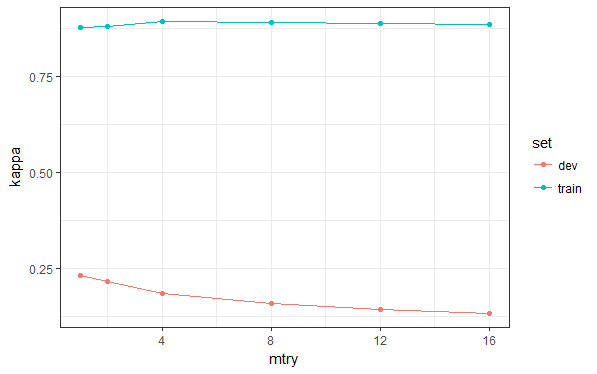

```
1] "mtry:  1"
[1] 0.876
Confusion Matrix and Statistics

          Reference
Prediction     0     1
         0 42043     4
         1   584    90

               Accuracy : 0.986
                 95% CI : (0.985, 0.987)
    No Information Rate : 0.998
    P-Value [Acc > NIR] : 1

                  Kappa : 0.231
 Mcnemar's Test P-Value : <2e-16

            Sensitivity : 0.95745
            Specificity : 0.98630
         Pos Pred Value : 0.13353
         Neg Pred Value : 0.99990
             Prevalence : 0.00220
         Detection Rate : 0.00211
   Detection Prevalence : 0.01578
      Balanced Accuracy : 0.97187

       'Positive' Class : 1

[1] "mtry:  2"
[1] 0.88
Confusion Matrix and Statistics

          Reference
Prediction     0     1
         0 41978     3
         1   649    91

               Accuracy : 0.985
                 95% CI : (0.984, 0.986)
    No Information Rate : 0.998
```

[output cut: 112 more lines]

```
    P-Value [Acc > NIR] : 1

                  Kappa : 0.133
 Mcnemar's Test P-Value : <2e-16

            Sensitivity : 0.97872
            Specificity : 0.97286
         Pos Pred Value : 0.07366
         Neg Pred Value : 0.99995
             Prevalence : 0.00220
         Detection Rate : 0.00215
   Detection Prevalence : 0.02924
      Balanced Accuracy : 0.97579

       'Positive' Class : 1
```

```r
ggplot(kappas) +
    aes(x = mtry, y = kappa, col = set) +
    geom_point() +
    geom_line() +
    scale_y_continuous(labels = scaleFUN)
```

The accuracy is very high, but that is to be expected when the classes are so imbalanced. Since only 0.2% of the observations are positive events, an accuracy of 99.8% is the No Information Rate.

A useful statistic is Kappa, since it takes into account the marginal distribution of the response variable, or the positive predictive value (precision) vs. recall (sensitivity).

Using these metrics, undersampling produces *reasonable* (but not amazing) results.

### 5.2. Oversampling

Undersampling may not work so well when we don’t have a lot of positive events, since it throws away much data. Still, I don’t want to have a huge amount of duplicated data, so I’m going to partially down-sample first.

```r
temp <- credit_train %>%
    filter(Class == 0) %>%
    sample_n(10000)

temp2 <- credit_train %>%
    filter(Class == 1)

credit_10000 <- rbind(temp, temp2)

credit_train_oversampled <- upSample(x = credit_10000,
                                     y = credit_10000$Class,
                                     yname = 'Class')

summary(credit_train_oversampled$Class)
```

```
    0     1
10000 10000
```

```r
kappas <- data.frame(mtry = NA, set = NA, kappa = NA)

for (mtry in c(1, 2, 4, 8, 12, 16)){
    set.seed(123456)
    fit_rf <- train(Class ~ . -Time,
                    data = credit_train_oversampled,
                    method = 'rf',
                    trControl = fit.controls,
                    tuneGrid = expand.grid(mtry = mtry),
                    n.trees = 3001,
                    metric = 'Kappa')

    fit_metrics <- test.class(fit_rf)
    kappas <- rbind(kappas, c(mtry, 'train', fit_rf$results$Kappa))
    kappas <- rbind(kappas, c(mtry, 'dev', fit_metrics$overall['Kappa']))
    print(paste('mtry: ', mtry))
    print(fit_rf$results$Kappa)
    print(fit_metrics)
}


kappas <- kappas %>%
    na.omit() %>%
    mutate(kappa = as.numeric(kappa),
           mtry = as.numeric(mtry))
```

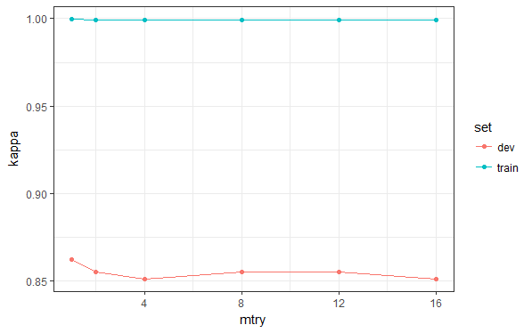

```
[1] "mtry:  1"
[1] 1
Confusion Matrix and Statistics

          Reference
Prediction     0     1
         0 42605     6
         1    22    88

               Accuracy : 0.999
                 95% CI : (0.999, 1)
    No Information Rate : 0.998
    P-Value [Acc > NIR] : 1.17e-15

                  Kappa : 0.862
 Mcnemar's Test P-Value : 0.00459

            Sensitivity : 0.93617
            Specificity : 0.99948
         Pos Pred Value : 0.80000
         Neg Pred Value : 0.99986
             Prevalence : 0.00220
         Detection Rate : 0.00206
   Detection Prevalence : 0.00257
      Balanced Accuracy : 0.96783

       'Positive' Class : 1

[1] "mtry:  2"
[1] 0.999
Confusion Matrix and Statistics

          Reference
Prediction     0     1
         0 42602     5
         1    25    89

               Accuracy : 0.999
                 95% CI : (0.999, 1)
    No Information Rate : 0.998
```

[output cut: 112 more lines]

```
    P-Value [Acc > NIR] : 3.79e-14

                  Kappa : 0.851
 Mcnemar's Test P-Value : 0.000328

            Sensitivity : 0.94681
            Specificity : 0.99939
         Pos Pred Value : 0.77391
         Neg Pred Value : 0.99988
             Prevalence : 0.00220
         Detection Rate : 0.00208
   Detection Prevalence : 0.00269
      Balanced Accuracy : 0.97310

       'Positive' Class : 1
```

```r
ggplot(kappas) +
    aes(x = mtry, y = kappa, col = set) +
    geom_point() +
    geom_line()
    scale_y_continuous(labels = scaleFUN)
```

### 5.3 SMOTE

Synthetic minority over-sampling technique is a hybrid method that undersamples the majority class and oversamples the minority class. Rather than being exact replicates, the minority observations are imputed by interpolating values from other minority class observations (using k nearest neighbours).

```r
# Note: SMOTE only takes Dataframes (Does not accept tbls)
# The default sampling is 200% over and 200% under, and k = 5
credit_train_smote <- DMwR::SMOTE(Class ~ . - Time,
                                  data = as.data.frame(credit_train))
summary(credit_train_smote$Class)
```

```
   0    1
1380 1035
```

```r
kappas <- data.frame(mtry = NA, set = NA, kappa = NA)

for (mtry in c(1, 2, 4, 8, 12, 16)){
    set.seed(123456)
    fit_rf <- train(Class ~ . -Time,
                    data = credit_train_smote,
                    method = 'rf',
                    trControl = fit.controls,
                    tuneGrid = expand.grid(mtry = mtry),
                    n.trees = 3001,
                    metric = 'Kappa')

    fit_metrics <- test.class(fit_rf)
    kappas <- rbind(kappas, c(mtry, 'train', fit_rf$results$Kappa))
    kappas <- rbind(kappas, c(mtry, 'dev', fit_metrics$overall['Kappa']))
    print(paste('mtry: ', mtry))
    print(fit_rf$results$Kappa)
    print(fit_metrics)
}


kappas <- kappas %>%
    na.omit() %>%
    mutate(kappa = as.numeric(kappa),
           mtry = as.numeric(mtry))
```

```r
ggplot(kappas) +
    aes(x = mtry, y = kappa, col = set) +
    geom_point() +
    geom_line()
    scale_y_continuous(labels = scaleFUN)
```

SMOTE appears to have some potential. The performance when `mtry = 1` is decent. It is definitely overfiting the training data.

[figure not shown]

[output not shown]

[output cut: 112 more lines]

[output not shown]

### 5.4 SMOTE v 2

I think the main reason why SMOTE is performing poorly compared to straight-up oversampling is the number of training observations. I’m going to try anoher random forest with SMOTE, but create a lot more minority cases.

```r
# Choose parameters that give roughly the same number and ~ 20,000 observations
credit_train_smote2 <- DMwR::SMOTE(Class ~ . - Time,
                                  data = as.data.frame(credit_train),
                                  perc.over = 2700,
                                  perc.under = 110) # Does not accept tbls
summary(credit_train_smote2$Class)
```

```
    0     1
10246  9660
```

```r
kappas <- data.frame(mtry = NA, set = NA, kappa = NA)

for (mtry in c(1, 2, 4, 8, 12, 16)){
    set.seed(123456)
    fit_rf <- train(Class ~ . -Time,
                    data = credit_train_smote2,
                    method = 'rf',
                    trControl = fit.controls,
                    tuneGrid = expand.grid(mtry = mtry),
                    n.trees = 3001,
                    metric = 'Kappa')

    fit_metrics <- test.class(fit_rf)
    kappas <- rbind(kappas, c(mtry, 'train', fit_rf$results$Kappa))
    kappas <- rbind(kappas, c(mtry, 'dev', fit_metrics$overall['Kappa']))
    print(paste('mtry: ', mtry))
    print(fit_rf$results$Kappa)
    print(fit_metrics)
}


kappas <- kappas %>%
    na.omit() %>%
    mutate(kappa = as.numeric(kappa),
           mtry = as.numeric(mtry))
```

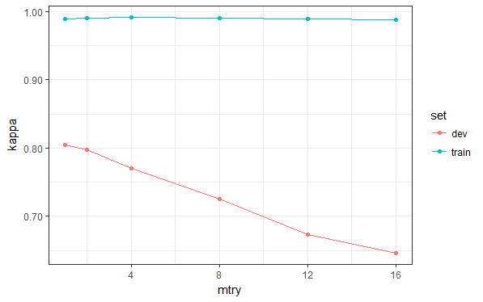

```
[1] "mtry:  1"
[1] 0.989
Confusion Matrix and Statistics

          Reference
Prediction     0     1
         0 42589     5
         1    38    89

               Accuracy : 0.999
                 95% CI : (0.999, 0.999)
    No Information Rate : 0.998
    P-Value [Acc > NIR] : 3.06e-09

                  Kappa : 0.805
 Mcnemar's Test P-Value : 1.06e-06

            Sensitivity : 0.94681
            Specificity : 0.99911
         Pos Pred Value : 0.70079
         Neg Pred Value : 0.99988
             Prevalence : 0.00220
         Detection Rate : 0.00208
   Detection Prevalence : 0.00297
      Balanced Accuracy : 0.97296

       'Positive' Class : 1

[1] "mtry:  2"
[1] 0.991
Confusion Matrix and Statistics

          Reference
Prediction     0     1
         0 42587     5
         1    40    89

               Accuracy : 0.999
                 95% CI : (0.999, 0.999)
    No Information Rate : 0.998
```

[output cut: 112 more lines]

```
    P-Value [Acc > NIR] : 0.647

                  Kappa : 0.646
 Mcnemar's Test P-Value : <2e-16

            Sensitivity : 0.94681
            Specificity : 0.99784
         Pos Pred Value : 0.49171
         Neg Pred Value : 0.99988
             Prevalence : 0.00220
         Detection Rate : 0.00208
   Detection Prevalence : 0.00424
      Balanced Accuracy : 0.97233

       'Positive' Class : 1
```

```r
ggplot(kappas) +
    aes(x = mtry, y = kappa, col = set) +
    geom_point() +
    geom_line() +
    scale_y_continuous(labels = scaleFUN)
```

### 5.5 No Sampling

I wasn’t going to run this initially because sampling methods are supposed to help improve training performance. However, I have noticed that models performing better on the training data tend to perform worse on the dev set.

Perhaps they have been overfitted, but it is also possible that the large disparity in prevalence of fraud between the training set and dev set make it hard to pick the best training model in advance.

```r
kappas <- data.frame(mtry = NA, set = NA, kappa = NA)

for (mtry in c(1, 2, 4, 8, 12, 16)){
    set.seed(123456)
    fit_rf <- train(Class ~ . -Time,
                    data = sample_n(credit_train, 20000),
                    method = 'rf',
                    trControl = fit.controls,
                    tuneGrid = expand.grid(mtry = mtry),
                    n.trees = 3001,
                    metric = 'Kappa')

    fit_metrics <- test.class(fit_rf)
    kappas <- rbind(kappas, c(mtry, 'train', fit_rf$results$Kappa))
    kappas <- rbind(kappas, c(mtry, 'dev', fit_metrics$overall['Kappa']))
    print(paste('mtry: ', mtry))
    print(fit_metrics)
}


kappas <- kappas %>%
    na.omit() %>%
    mutate(kappa = as.numeric(kappa),
           mtry = as.numeric(mtry))
```

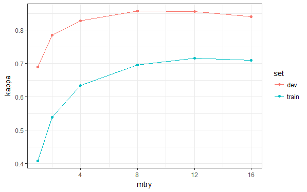

```
[1] "mtry:  1"
Confusion Matrix and Statistics

          Reference
Prediction     0     1
         0 42626    44
         1     1    50

               Accuracy : 0.999
                 95% CI : (0.999, 0.999)
    No Information Rate : 0.998
    P-Value [Acc > NIR] : 1.42e-08

                  Kappa : 0.689
 Mcnemar's Test P-Value : 3.83e-10

            Sensitivity : 0.53191
            Specificity : 0.99998
         Pos Pred Value : 0.98039
         Neg Pred Value : 0.99897
             Prevalence : 0.00220
         Detection Rate : 0.00117
   Detection Prevalence : 0.00119
      Balanced Accuracy : 0.76595

       'Positive' Class : 1

[1] "mtry:  2"
Confusion Matrix and Statistics

          Reference
Prediction     0     1
         0 42625    32
         1     2    62

               Accuracy : 0.999
                 95% CI : (0.999, 0.999)
    No Information Rate : 0.998
    P-Value [Acc > NIR] : 9.23e-13

```

[output cut: 106 more lines]

```
    P-Value [Acc > NIR] : 3.43e-16

                  Kappa : 0.84
 Mcnemar's Test P-Value : 0.000532

            Sensitivity : 0.75532
            Specificity : 0.99991
         Pos Pred Value : 0.94667
         Neg Pred Value : 0.99946
             Prevalence : 0.00220
         Detection Rate : 0.00166
   Detection Prevalence : 0.00176
      Balanced Accuracy : 0.87761

       'Positive' Class : 1
```

```r
ggplot(kappas) +
    aes(x = mtry, y = kappa, col = set) +
    geom_point() +
    geom_line()
    scale_y_continuous(labels = scaleFUN)
```

## 6. Classification

In this section I will do some parameter searches across a number of classification models using either Oversampled or SMOTE-sampled data. I’ll check the performance against the dev set and select a few candidate models.

In a later section I’ll manually play with each of the most promising models and try to eek out additional performance before finally testing 1-3 models on the test set to get an unbiased estimate of error.